# Lab 10: Piece-wise Linear Model

Bayesian Statistics

Daniel Carpenter

March, 2022

# Change Point Regression Models & Lab Overview

## Overview and Topics

- In this lab we will investigate another class of models which are extremely flexible in their application.
- This topic can be seen as piecewise regression.

## The Change Point Model Expression

$$y_i \sim N(\mu_i, \sigma^2)$$
$$\mu_i = \beta_0 + \beta_1 x_i + \beta_2(x_i -\theta)I_{(1, x_i\ge\theta,\; 0\; else)}$$

## Example: Stagnant Water: Change point model

$y_i$ is the log flow rate down an inclined channel, and $x_i$ is the log height of stagnant surface layers of different surfactants. The rate of decline in flow rate seems to suddenly increase around $x=0$.

## Data Overview

```r
dataList = list(
  y = c(1.12, 1.12, 0.99, 1.03,
        0.92, 0.90, 0.81, 0.83,
        0.65, 0.67, 0.60,  0.59,
        0.51, 0.44, 0.43, 0.43,
        0.33, 0.30, 0.25, 0.24,
        0.13, -0.01, -0.13, -0.14,
        -0.30, -0.33, -0.46,-0.43, -0.65),

  x = c(-1.39, -1.39, -1.08, -1.08,
        -0.94, -0.80, -0.63, -0.63,
        -0.25, -0.25, -0.12, -0.12,
        0.01, 0.11, 0.11, 0.11,
        0.25, 0.25, 0.34, 0.34,
        0.44, 0.59, 0.70, 0.70,
        0.85, 0.85,  0.99, 0.99, 1.19),

  N = 29)
```

# Task 1 - Review Data and 2-Linear Pieces

## Plot the data using ggplot

```r
df = data.frame(x = dataList$x, y=dataList$y)

head(df)
```

```
##       x    y
## 1 -1.39 1.12
## 2 -1.39 1.12
## 3 -1.08 0.99
## 4 -1.08 1.03
## 5 -0.94 0.92
## 6 -0.80 0.90
```

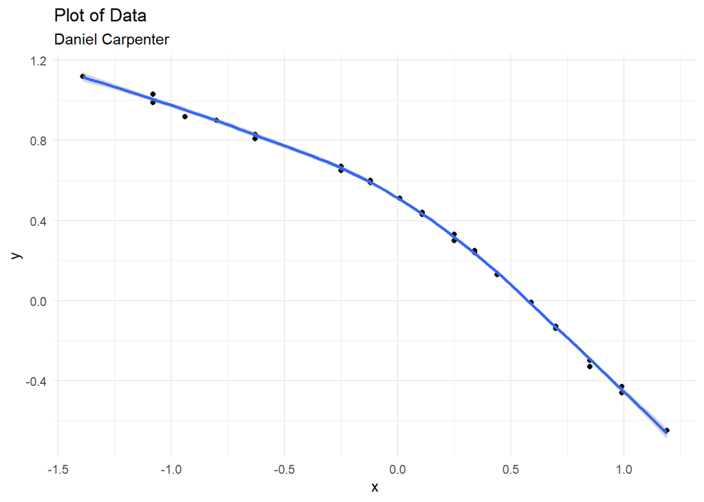

```r
library(ggplot2)
basePlot <- ggplot(df, aes(x=x, y=y)) +
              geom_point() +
              geom_smooth(method = 'loess', se = TRUE) +
              theme_minimal() +
              labs(title = 'Plot of Data',
                   subtitle = 'Daniel Carpenter')
basePlot
```

# Task 2 - Create JAGS Model

## JAGS Model for Piece-wise Regression

```r
model {
  for (i in 1:N) {
    y[i]    ~ dnorm(mu[i], tau)
    mu[i]  <- beta0 + beta[1]*x[i] + beta[2]*(x[i] - theta)
            * step(x[i] - theta)
  }
  tau       ~ dgamma(0.001, 0.001)
  beta0     ~ dnorm(0.0, 1.0E-6)

  for (j in 1:2) {
    beta[j] ~ dnorm(0.0, 1.0E-6)
  }
  sigma    <- 1/sqrt(tau)
  theta     ~ dunif(-1.3, 1.1)

  int2 <- beta0 - beta[1]*theta
  slope2 <- beta[1] + beta[2]
}
```

### `step()` Function

- In the expression of the analytical model we used $I_{(1, x_i\ge\theta,\; 0\; else)}$
- What jags function is used for $I$? `step()`

### A prior is placed on $\tau$

What is the mean and variance of the prior distribution for $\tau$?

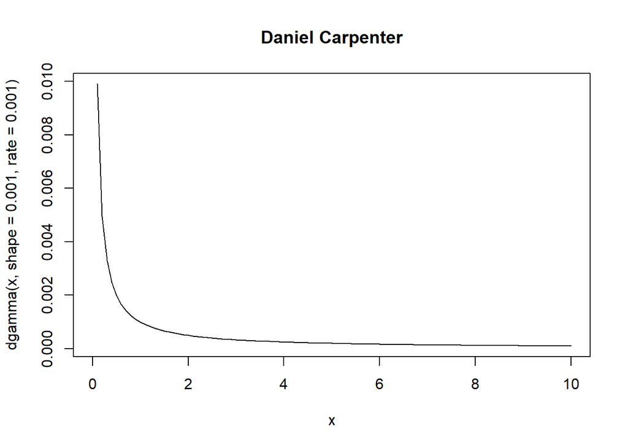

```r
# What it looks like
curve(dgamma(x, shape = 0.001, rate = 0.001), xlim = c(0, 10))
title(main = 'Daniel Carpenter')
```

```r
# Mean
0.001/0.001
```

```
## [1] 1
```

```r
# Variance
0.001/0.001^2
```

```
## [1] 1000
```

```r
# Variance
```

# Task 3 - Create Full-JAGS Scripts

## Create JAGS Script with Piece-wise Regression

Make a complete Jags script to run the model. You can use the script below and alter it to fit.

```r
library(rjags)
#Define the model:
modelString = "
model {
  for (i in 1:N) {
    y[i]    ~ dnorm(mu[i], tau)
    mu[i]  <- beta0 + beta[1]*x[i] + beta[2]*(x[i] - theta)
            * step(x[i] - theta)
  }
  tau       ~ dgamma(0.001, 0.001)
  beta0     ~ dnorm(0.0, 1.0E-6)

  for (j in 1:2) {
    beta[j] ~ dnorm(0.0, 1.0E-6)
  }
  sigma    <- 1/sqrt(tau)
  theta     ~ dunif(-1.3, 1.1)

  int2 <- beta0 - beta[1]*theta
  slope2 <- beta[1] + beta[2]
}
" # close quote for modelString
writeLines( modelString , con="TEMPmodel.txt" )

initsList = list(tau = 1, beta0 = 2, beta = c(1, 2), theta = 1)

# Run the chains:
jagsModel = jags.model( file="TEMPmodel.txt" , data=dataList , inits=initsList ,
                        n.chains=3 , n.adapt=500 )
# Show how the model is ran - realSlicer is slow. Conjugate is fast
list.samplers(jagsModel)
```

```
## $`bugs::ConjugateNormal`
## [1] "beta[2]"
##
## $`bugs::ConjugateNormal`
## [1] "beta[1]"
##
## $`bugs::ConjugateGamma`
## [1] "tau"
##
## $`bugs::ConjugateNormal`
## [1] "beta0"
##
## $`base::RealSlicer`
## [1] "theta"
```

```r
update( jagsModel , n.iter=500 )
codaSamples = coda.samples( jagsModel , variable.names=c("tau", "sigma",
                                                         'beta', 'beta0', 'theta',
                                                         'int2', 'slope2'),
                            n.iter=33340 )
save( codaSamples , file=paste0("lab10","Mcmc.Rdata") )

# Output of model
summary(codaSamples)
```

```
##
## Iterations = 1001:34340
## Thinning interval = 1
## Number of chains = 3
## Sample size per chain = 33340
##
## 1. Empirical mean and standard deviation for each variable,
##    plus standard error of the mean:
##
##               Mean        SD  Naive SE Time-series SE
## beta[1]   -0.41981 1.500e-02 4.743e-05      2.424e-04
## beta[2]   -0.59402 2.100e-02 6.641e-05      2.085e-04
## beta0      0.54704 1.293e-02 4.089e-05      2.272e-04
## int2       0.55940 7.987e-03 2.525e-05      7.284e-05
## sigma      0.02207 3.285e-03 1.039e-05      1.635e-05
## slope2    -1.01384 1.771e-02 5.598e-05      1.884e-04
## tau     2184.51122 6.183e+02 1.955e+00      2.935e+00
## theta      0.02858 3.293e-02 1.041e-04      5.877e-04
##
## 2. Quantiles for each variable:
##
##               2.5%        25%        50%        75%      97.5%
## beta[1]   -0.44947 -4.296e-01   -0.42008   -0.41011   -0.38974
## beta[2]   -0.63520 -6.078e-01   -0.59412   -0.58027   -0.55234
## beta0      0.52190  5.387e-01    0.54661    0.55523    0.57352
## int2       0.54337  5.543e-01    0.55946    0.56456    0.57498
## sigma      0.01678  1.975e-02    0.02169    0.02397    0.02958
## slope2    -1.04898 -1.025e+00   -1.01378   -1.00223   -0.97920
## tau     1142.89560  1.741e+03 2126.32051 2564.95039 3551.77576
## theta     -0.03631  6.915e-03    0.03045    0.04963    0.08961
```

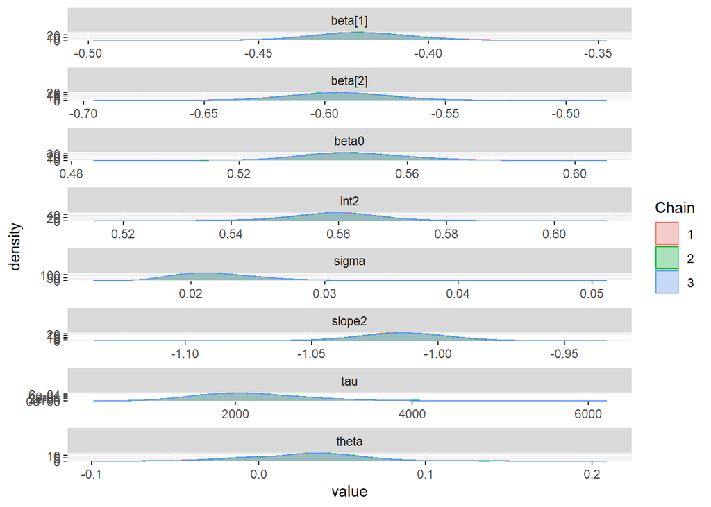

```r
# Plot the model output
library(ggmcmc)
s = ggs(codaSamples)
ggs_density(s)
```

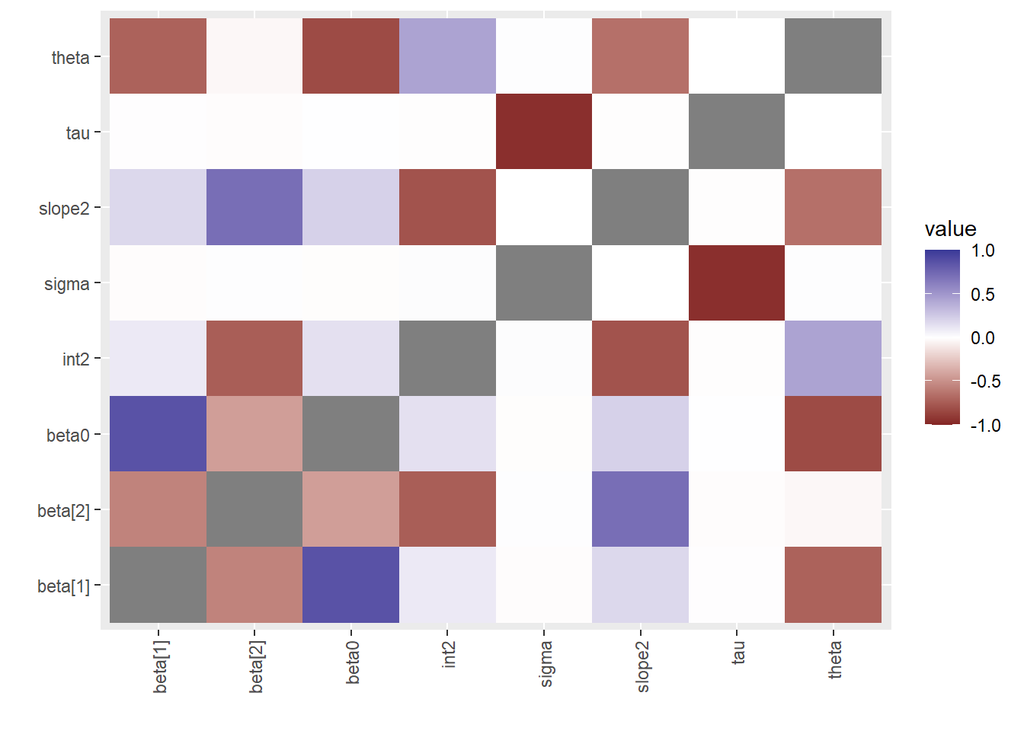

```r
ggs_crosscorrelation(s)
```

# Task 4 - Retrieve Point Estimates from JAGS Model

Run the model and make point and interval estimates.

```r
su = summary(codaSamples)
su
```

```
##
## Iterations = 1001:34340
## Thinning interval = 1
## Number of chains = 3
## Sample size per chain = 33340
##
## 1. Empirical mean and standard deviation for each variable,
##    plus standard error of the mean:
##
##               Mean        SD  Naive SE Time-series SE
## beta[1]   -0.41981 1.500e-02 4.743e-05      2.424e-04
## beta[2]   -0.59402 2.100e-02 6.641e-05      2.085e-04
## beta0      0.54704 1.293e-02 4.089e-05      2.272e-04
## int2       0.55940 7.987e-03 2.525e-05      7.284e-05
## sigma      0.02207 3.285e-03 1.039e-05      1.635e-05
## slope2    -1.01384 1.771e-02 5.598e-05      1.884e-04
## tau     2184.51122 6.183e+02 1.955e+00      2.935e+00
## theta      0.02858 3.293e-02 1.041e-04      5.877e-04
##
## 2. Quantiles for each variable:
##
##               2.5%        25%        50%        75%      97.5%
## beta[1]   -0.44947 -4.296e-01   -0.42008   -0.41011   -0.38974
## beta[2]   -0.63520 -6.078e-01   -0.59412   -0.58027   -0.55234
## beta0      0.52190  5.387e-01    0.54661    0.55523    0.57352
## int2       0.54337  5.543e-01    0.55946    0.56456    0.57498
## sigma      0.01678  1.975e-02    0.02169    0.02397    0.02958
## slope2    -1.04898 -1.025e+00   -1.01378   -1.00223   -0.97920
## tau     1142.89560  1.741e+03 2126.32051 2564.95039 3551.77576
## theta     -0.03631  6.915e-03    0.03045    0.04963    0.08961
```

### Interpret the estimates:

- The mean and standard deviation for each monitored variable can be shown above. For example, the mean $\mu$ of $\beta_1$ is around -0.42 and its standard deviation $\sigma$ is around 1.499e-02
- We can also analyze the credibility intervals for each variable. For example, there is a 95% probability that $\beta_1$’s mean will approximately fall between -0.449 and -0.389.
- Above values rounded since each MCMC run varies in results (since it is an estimation)

# Task 5 - Plot Piece-Wise Estimates on Data

Plot the estimating lines onto the data

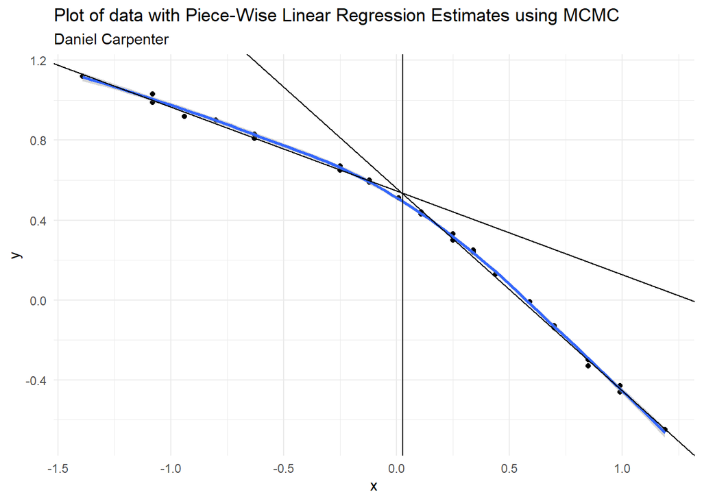

```r
# Create objects using summary stats
beta0  = su$statistics[,'Mean']['beta0']
beta1  = su$statistics[,'Mean']['beta[1]']
beta2  = su$statistics[,'Mean']['beta[2]']
int2   = su$statistics[,'Mean']['int2']
slope2 = su$statistics[,'Mean']['slope2']
theta  = su$statistics[,'Mean']['theta']

# Plot the two estimated linear pieces with the cuttoff point
basePlot +
  geom_abline(intercept = beta0, slope = beta1)  + # Piece 1
  geom_abline(intercept = int2,  slope = slope2) + # Piece 2
  geom_vline(xintercept = theta)                 + # Intersection
  labs(title = 'Plot of data with Piece-Wise Linear Regression Estimates using MCMC')
```